# Project 1

Josh Stim

2023-09-06

# Chocolate Bars

## Part 0. Getting started

Install relevant packages

```r
## Install the tidyverse package if you don't have it
if (!require("tidyverse", quietly = TRUE)) {
    install.packages("tidyverse")
}
```

Load relevant packages from library

```r
library(tidyverse)
library(tidytuesdayR)
library(here)
library(gapminder)
library(gghalves)
```

Upload chocolate data

```r
# creates data folder if one doesn't exist locally
if (!dir.exists(here("data"))) {
  dir.create(here("data"))
}

# saves data only if it doesn't exist locally
if (!file.exists(here("data","chocolate.RDS"))) {
  url_csv <- "https://raw.githubusercontent.com/rfordatascience/tidytuesday/master/data/2022/2022-01-18/chocolate.csv"
  chocolate <- readr::read_csv(url_csv)

  # save the file to RDS objects
  saveRDS(chocolate, file = here("data", "chocolate.RDS"))
}

# read in the .RDS locally from our computing environment
chocolate <- readRDS(here("data", "chocolate.RDS"))
as_tibble(chocolate)
```

```
## # A tibble: 2,530 × 10
##      ref company_manufacturer company_location review_date
##    <dbl> <chr>                <chr>                  <dbl>
##  1  2454 5150                 U.S.A.                  2019
##  2  2458 5150                 U.S.A.                  2019
##  3  2454 5150                 U.S.A.                  2019
##  4  2542 5150                 U.S.A.                  2021
##  5  2546 5150                 U.S.A.                  2021
##  6  2546 5150                 U.S.A.                  2021
##  7  2542 5150                 U.S.A.                  2021
##  8   797 A. Morin             France                  2012
##  9   797 A. Morin             France                  2012
## 10  1011 A. Morin             France                  2013
## # ℹ 2,520 more rows
## # ℹ 6 more variables: country_of_bean_origin <chr>,
## #   specific_bean_origin_or_bar_name <chr>, cocoa_percent <chr>,
## #   ingredients <chr>, most_memorable_characteristics <chr>, rating <dbl>
```

## Part 1. Explore Data

### 1.1. Make a Histogram

*Make a histogram of the rating scores to visualize the overall distribution of scores. Change the number of bins from the default to 10, 15, 20, and 25. Pick on the one that you think looks the best. Explain what the difference is when you change the number of bins and explain why you picked the one you did.*

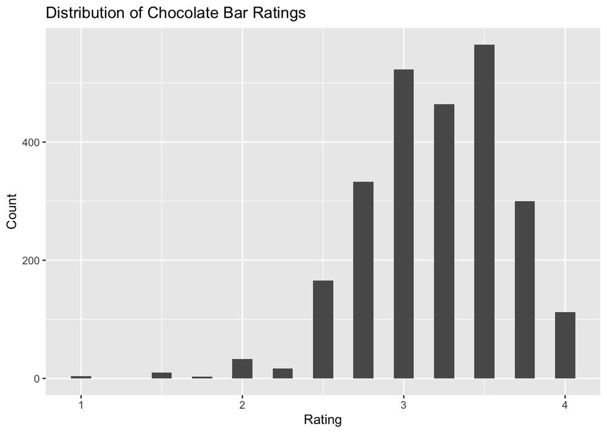

```r
chocolate %>%
  ggplot(aes(x = rating)) +
    geom_histogram(bins = 25) +
    labs(title = "Distribution of Chocolate Bar Ratings",
         x = "Rating", y = "Count")
```

**Josh:** Above is a histogram of the chocolate bar rating scores. I decided to use 25 bins, since this ensures that each bin represents the frequency of only one numerical rating. Additionally, the bars in the histogram are centered on the rating they represent, making it easier to interpret.

### 1.2. Count reviews for each country of bean origin

*How many reviews come from each country of bean origin?*

```r
n_reviews_by_cobo <- chocolate %>%
  group_by(country_of_bean_origin) %>%
  summarize(n_reviews = n()) %>%
  arrange(desc(n_reviews))

n_reviews_by_cobo
```

```
## # A tibble: 62 × 2
##    country_of_bean_origin n_reviews
##    <chr>                      <int>
##  1 Venezuela                    253
##  2 Peru                         244
##  3 Dominican Republic           226
##  4 Ecuador                      219
##  5 Madagascar                   177
##  6 Blend                        156
##  7 Nicaragua                    100
##  8 Bolivia                       80
##  9 Colombia                      79
## 10 Tanzania                      79
## # ℹ 52 more rows
```

### 1.3. Summarize ratings of beans from Ecuador

*What is the average rating scores from reviews of chocolate bars that* *have Ecuador as country_of_bean_origin in this dataset? For this same* *set of reviews, also calculate*

*(1) the total number of reviews and (2) the standard deviation of the rating scores.*

```r
chocolate.beans_from_equador <-
  chocolate %>%
  filter(country_of_bean_origin == "Ecuador")

chocolate.beans_from_equador %>%
  summarize(mean = mean(rating), sd = sd(rating), total = n())
```

```
## # A tibble: 1 × 3
##    mean    sd total
##   <dbl> <dbl> <int>
## 1  3.16 0.512   219
```

### 1.4. Manufacturer with best chocolate from Ecuadorian beans

*Which company manufacturer makes the best chocolate (or has the highest ratings on average) with beans from Ecuador?*

```r
chocolate.beans_from_equador %>%
  group_by(company_manufacturer) %>%
  summarise(mean_rating = mean(rating)) %>%
  filter(mean_rating == max(mean_rating))
```

```
## # A tibble: 5 × 2
##   company_manufacturer   mean_rating
##   <chr>                        <dbl>
## 1 Amano                            4
## 2 Benoit Nihant                    4
## 3 Beschle (Felchlin)               4
## 4 Durci                            4
## 5 Smooth Chocolator, The           4
```

**Josh:** These are the five companies with the highest mean rating using beans from Ecuador.

### 1.5. Mean ratings for all countries of origin

*Calculate the average rating across all country of origins for beans. Which top 3 countries have the highest ratings on average?*

```r
mean_rating_by_bean_origin <-
  chocolate %>%
  group_by(country_of_bean_origin) %>%
  summarize(n_reviews = n(), mean_rating = mean(rating)) %>%
  arrange(desc(mean_rating))

mean_rating_by_bean_origin
```

```
## # A tibble: 62 × 3
##    country_of_bean_origin n_reviews mean_rating
##    <chr>                      <int>       <dbl>
##  1 Tobago                         2        3.62
##  2 China                          1        3.5
##  3 Sao Tome & Principe            2        3.5
##  4 Solomon Islands               10        3.45
##  5 Congo                         11        3.32
##  6 Thailand                       5        3.3
##  7 Cuba                          12        3.29
##  8 Vietnam                       73        3.29
##  9 Papua New Guinea              50        3.28
## 10 Madagascar                   177        3.27
## # ℹ 52 more rows
```

**Josh:** We see that Tobago, China, and Sao Tome & Principe have the highest average ratings. However, note that these countries have very few reviews, so is it really fair to say that these countries make the best beans?

### 1.6. Mean ratings from countries with $\geq$ 10 reviews

*Following up, remove any countries of bean origins that have less than 10 chocolate bar reviews. Now, which top 3 countries have the highest ratings on average?*

```r
mean_rating_by_bean_origin %>%
  filter(n_reviews >= 10)
```

```
## # A tibble: 35 × 3
##    country_of_bean_origin n_reviews mean_rating
##    <chr>                      <int>       <dbl>
##  1 Solomon Islands               10        3.45
##  2 Congo                         11        3.32
##  3 Cuba                          12        3.29
##  4 Vietnam                       73        3.29
##  5 Papua New Guinea              50        3.28
##  6 Madagascar                   177        3.27
##  7 Haiti                         30        3.27
##  8 Brazil                        78        3.26
##  9 Guatemala                     62        3.26
## 10 Nicaragua                    100        3.26
## # ℹ 25 more rows
```

**Josh:** After removing countries with fewer than 10 reviews, we see that **Solomon Islands**, **Congo**, and **Cuba** have the highest average bean ratings.

### 1.7. Relationship between percent chocolate and rating

*For this last part, let’s explore the relationship between percent chocolate and ratings.*

*a) Identify the countries of bean origin with at least 50 reviews. Remove reviews from countries are not in this list.*

**Josh:** Below is a subset of the chocolate dataset containing data from only countries that had 50 or more reviews.

```r
chocolate.cobo_geq_50 <- chocolate %>%
  group_by(country_of_bean_origin) %>%
  filter(n() >= 50) %>%
  ungroup()

chocolate.cobo_geq_50
```

```
## # A tibble: 2,007 × 10
##      ref company_manufacturer company_location review_date
##    <dbl> <chr>                <chr>                  <dbl>
##  1  2454 5150                 U.S.A.                  2019
##  2  2458 5150                 U.S.A.                  2019
##  3  2454 5150                 U.S.A.                  2019
##  4  2546 5150                 U.S.A.                  2021
##  5   797 A. Morin             France                  2012
##  6   797 A. Morin             France                  2012
##  7  1015 A. Morin             France                  2013
##  8  1011 A. Morin             France                  2013
##  9  1011 A. Morin             France                  2013
## 10  1015 A. Morin             France                  2013
## # ℹ 1,997 more rows
## # ℹ 6 more variables: country_of_bean_origin <chr>,
## #   specific_bean_origin_or_bar_name <chr>, cocoa_percent <chr>,
## #   ingredients <chr>, most_memorable_characteristics <chr>, rating <dbl>
```

*(b) Using the variable describing the chocolate percentage for each review, create a new column that groups chocolate percentages into one of four groups:* (i)* $<60 \%$, *(ii)* $\geq 60\%$ to $<70\%$, *(iii)* $\geq 70 \%$ to $\leq 90 \%$, *and (iii)* $\geq 90 \%$.

*(Hint check out the substr() function in base R and the case_when() function from dplyr – see example below).*

```r
tmp <- substr(chocolate.cobo_geq_50$cocoa_percent,1,2)
chocolate.cobo_geq_50$cocoa_percent_discrete <-
  case_when(
  tmp < 60 ~ "<60%",
  tmp >= 60 & tmp < 70 ~ ">=60% to <70%",
  tmp >= 70 & tmp < 90 ~ ">=70% to <90%",
  tmp >= 90 ~ ">=90%"
  ) %>%
  factor()

levels(chocolate.cobo_geq_50$cocoa_percent_discrete)
```

```
## [1] "<60%"          ">=60% to <70%" ">=70% to <90%" ">=90%"
```

*(c) Using the new column described in #2, re-order the factor levels (if needed) to be starting with the smallest percentage group and increasing to the largest percentage group (Hint check out the fct_relevel() function from forcats).*

```r
chocolate.cobo_geq_50$cocoa_percent_discrete <-
  chocolate.cobo_geq_50$cocoa_percent_discrete %>%
  fct_relevel(sort)

levels(chocolate.cobo_geq_50$cocoa_percent_discrete)
```

```
## [1] "<60%"          ">=60% to <70%" ">=70% to <90%" ">=90%"
```

*(d) For each country, make a set of four side-by-side boxplots plotting the groups on the x-axis and the ratings on the y-axis. These plots should be faceted by country.*

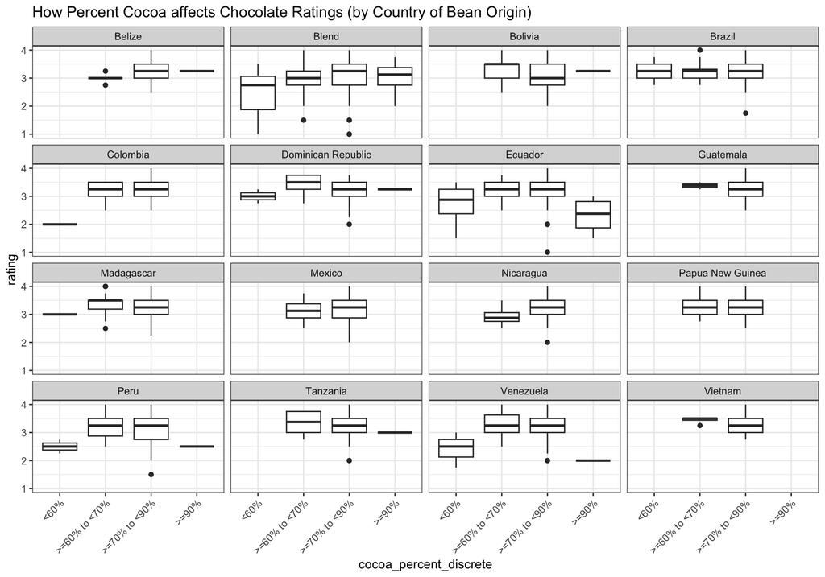

```r
chocolate.cobo_geq_50 %>%
  ggplot(aes(x = cocoa_percent_discrete, y = rating)) +
  geom_boxplot() +
  facet_wrap(~country_of_bean_origin) +
  theme_bw() +
  theme(axis.text.x = element_text(angle = 45, hjust = 1)) +
  labs(title = "How Percent Cocoa affects Chocolate Ratings (by Country of Bean Origin)")
```

**Josh:** Overall, it seems that cocoa percentages between 60% and 90% yield better ratings compared to those $<60\%$ or $>90\%$. This observation is generally consistent across countries of bean origin, the exceptions of Brazil and (perhaps) Blend. It is also worth noting that over a quarter of countries produced no chocolate with $<60\%$ or $>90\%$ cocoa.

*On average, which category of chocolate percentage is most highly rated? Do these countries mostly agree or are there disagreements?*

```r
#collapsing across countries
chocolate.cobo_geq_50 %>%
  group_by(cocoa_percent_discrete) %>%
  summarize(n = n(), mean = mean(rating), sd = sd(rating))
```

```
## # A tibble: 4 × 4
##   cocoa_percent_discrete     n  mean    sd
##   <fct>                  <int> <dbl> <dbl>
## 1 <60%                      41  2.66 0.670
## 2 >=60% to <70%            270  3.25 0.436
## 3 >=70% to <90%           1682  3.22 0.435
## 4 >=90%                     14  2.75 0.650
```

**Josh:** Based on the boxplots (and the table) we see that cocoa percentages between 60% and 90% generally yield higher ratings compared to cocoa percentages below 60% or above 90%. Additionally, it seems that the most common cocoa percentage is $\geq 70 \%$ to $90 \%$, as nearly 84% of all chocolates with 50 or more reviews were in this category.

## Part 2. Join two datasets together

### 2.0. Load gapminder data

```r
gapminder.data <- unique(gapminder::gapminder[, c("country", "continent")])
```

### 2.1. Merge `gapminder$continent` to `chocolate` dataset

*Use this dataset it to create a new column called continent in our chocolate dataset that contains the continent name for each review where the country of bean origin is.*

*Also manually add continents that have not been matched.*

```r
# create copy of raw dataframe
chocolate.with_cont <- chocolate

# standardize spelling of certain countries in chocolate.with_cont.country_of_bean_origin
chocolate.with_cont$country_of_bean_origin <-
  case_when(
    chocolate.with_cont$country_of_bean_origin %in% c("Trinidad", "Tobago") ~ "Trinidad and Tobago",
    chocolate.with_cont$country_of_bean_origin %in% c("Sao Tome", "Principe", "Sao Tome & Principe") ~ "Sao Tome and Principe",
    chocolate.with_cont$country_of_bean_origin %in% c("Congo", "DR Congo") ~ "Congo, Dem. Rep.",
    chocolate.with_cont$country_of_bean_origin %in% c("U.S.A.", "USA") ~ "United States",
    .default = as.character(chocolate.with_cont$country_of_bean_origin)
  )

# join chocolate with gapminder.data by country
chocolate.with_cont <- left_join(chocolate.with_cont, gapminder.data,
                       join_by(country_of_bean_origin == country))

# manually add continents to chocolate for countries not listed in gapminder.data
chocolate.with_cont$continent <-
  case_when(
    chocolate.with_cont$country_of_bean_origin %in%
      c("Belize", "Grenada", "Martinique", "St. Lucia", "St.Vincent-Grenadines", "Suriname") ~ "Americas",
    chocolate.with_cont$country_of_bean_origin %in%
      c("Burma", "Sumatra", "Sulawesi") ~ "Asia",
    chocolate.with_cont$country_of_bean_origin %in%
      c("Ivory Coast") ~ "Africa",
    chocolate.with_cont$country_of_bean_origin %in%
      c("Fiji", "Papua New Guinea", "Vanuatu", "Solomon Islands", "Samoa") ~ "Oceania",
    .default = as.character(chocolate.with_cont$continent)
  )
```

### 2.2 - 2.3. Remove countries named “Blend” or with <10 reviews

*Only keep reviews that have reviews from countries of bean origin with at least 10 reviews.* *Also, remove the country of bean origin named “Blend”.*

```r
chocolate.with_cont.cobo_geq_10 <- chocolate.with_cont %>%
  filter(country_of_bean_origin != "Blend") %>%
  group_by(country_of_bean_origin) %>%
  filter(n() >= 10) %>%
  ungroup()

chocolate.with_cont.cobo_geq_10
```

```
## # A tibble: 2,298 × 11
##      ref company_manufacturer company_location review_date
##    <dbl> <chr>                <chr>                  <dbl>
##  1  2454 5150                 U.S.A.                  2019
##  2  2458 5150                 U.S.A.                  2019
##  3  2454 5150                 U.S.A.                  2019
##  4  2542 5150                 U.S.A.                  2021
##  5  2546 5150                 U.S.A.                  2021
##  6  2546 5150                 U.S.A.                  2021
##  7  2542 5150                 U.S.A.                  2021
##  8   797 A. Morin             France                  2012
##  9   797 A. Morin             France                  2012
## 10  1015 A. Morin             France                  2013
## # ℹ 2,288 more rows
## # ℹ 7 more variables: country_of_bean_origin <chr>,
## #   specific_bean_origin_or_bar_name <chr>, cocoa_percent <chr>,
## #   ingredients <chr>, most_memorable_characteristics <chr>, rating <dbl>,
## #   continent <chr>
```

### 2.4. Make continent-by-rating violin plot

*Make a set of violin plots with ratings on the y-axis and continents on the x-axis.*

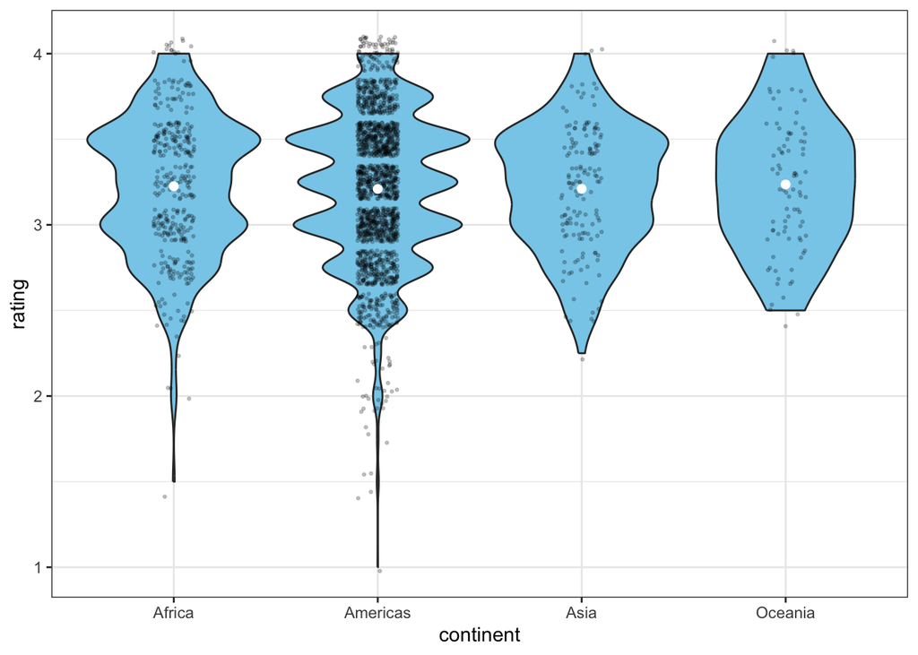

```r
chocolate.with_cont.cobo_geq_10 %>%
  ggplot(aes(x = continent, y = rating)) +
  geom_violin(fill = "skyblue") +
  geom_jitter(size = 0.5, width = 0.1, alpha = 0.2) +
  stat_summary(fun = "mean", color = "white", size = 0.3) +
  theme(legend.position = "none") +
  theme_bw()
```

**Josh:** Overall, there does not seem to be a difference in mean ratings across continents. However you may notice that a large proportion of ratings are coming from `Americas`. This may be due to the fact that `Americas` actually includes two continents: North and South America.

**Josh:** Also, you may notice that, while the mean ratings are similar across continents, most of the lower rated chocolate bars (rating $\leq 2$) come from the Americas. This may be due to the fact that we have so many samples from `Americas`, and so it shouldn’t be too surprising to see a greater number of extreme ratings compared to the other, less sampled continents.

## Part 3. Convert Wide Data into Long Data

### 3.1. Create an indicator column for each ingredient

*Create a new set of columns titled beans, sugar, cocoa_butter, vanilla, letchin, and salt that contain a 1 or 0 representing whether or not that review for the chocolate bar contained that ingredient (1) or not (0).*

```r
# convert missing ingredient cell to empty string
chocolate$ingredients[is.na(chocolate$ingredients)] <- " "

# create ingredient columns
chocolate.with_ingredients <-
  chocolate %>%
  mutate(
    beans = str_detect(ingredients, "B"),
    cocoa_butter = str_detect(ingredients, "C"),
    vanilla = str_detect(ingredients, "V"),
    letchin = str_detect(ingredients, "L"),
    salt = str_detect(ingredients, "Sa"),
    sugar = str_detect(ingredients, "S")
  )
```

### 3.2. Create an indicator column for each characteristic

*Create a new set of columns titled char_cocoa, char_sweet, char_nutty, char_creamy, char_roasty, char_earthy that contain a 1 or 0 representing whether or not that the most memorable characteristic for the chocolate bar had that word (1) or not (0). For example, if the word “sweet” appears in the most_memorable_characteristics, then record a 1, otherwise a 0 for that review in the char_sweet column (Hint: check out str_detect() from the stringr package).*

```r
chocolate.with_ingredients <-
  chocolate.with_ingredients %>%
  mutate(
    char_cocoa = str_detect(most_memorable_characteristics, "cocoa"),
    char_sweet = str_detect(most_memorable_characteristics, "sweet"),
    char_nutty = str_detect(most_memorable_characteristics, "nutty"),
    char_creamy = str_detect(most_memorable_characteristics, "creamy"),
    char_roasty = str_detect(most_memorable_characteristics, "roasty"),
    char_earthy = str_detect(most_memorable_characteristics, "earthy")
  )
```

### 3.3. Percent of bars that had each ingredient/characteristic (by year)

*For each year (i.e. review_date), calculate the mean value in each new column you created across all reviews for that year. (Hint: If all has gone well thus far, you should have a dataset with 16 rows and 13 columns).*

```r
table.mean_ingredients_by_year <-
  chocolate.with_ingredients %>%
  select(review_date,beans:char_earthy) %>%
  group_by(review_date) %>%
  summarize(across(beans:char_earthy, mean))

table.mean_ingredients_by_year
```

```
## # A tibble: 16 × 13
##    review_date beans cocoa_butter vanilla letchin    salt sugar char_cocoa
##          <dbl> <dbl>        <dbl>   <dbl>   <dbl>   <dbl> <dbl>      <dbl>
##  1        2006 0.968        0.903  0.694   0.694  0       0.968     0.210
##  2        2007 0.945        0.767  0.548   0.384  0       0.945     0.342
##  3        2008 0.913        0.75   0.359   0.511  0       0.902     0.109
##  4        2009 0.919        0.772  0.325   0.341  0       0.919     0.146
##  5        2010 0.855        0.709  0.227   0.391  0.00909 0.855     0.218
##  6        2011 0.939        0.693  0.160   0.160  0.0491  0.939     0.172
##  7        2012 0.928        0.675  0.186   0.124  0.0722  0.928     0.0876
##  8        2013 0.967        0.776  0.208   0.295  0.0164  0.956     0.175
##  9        2014 0.984        0.644  0.0688  0.121  0.0324  0.984     0.0607
## 10        2015 0.986        0.546  0.0599  0.120  0       0.979     0.127
## 11        2016 0.982        0.594  0.0507  0.106  0.00922 0.977     0.0922
## 12        2017 0.981        0.562  0.0286  0.133  0.00952 0.981     0.133
## 13        2018 0.987        0.596  0.0614  0.132  0       0.987     0.180
## 14        2019 1            0.679  0.0259  0.202  0       1         0.259
## 15        2020 1            0.568  0.0370  0.0247 0       1         0.284
## 16        2021 1            0.646  0.0114  0.08   0       0.994     0.297
## # ℹ 5 more variables: char_sweet <dbl>, char_nutty <dbl>, char_creamy <dbl>,
## #   char_roasty <dbl>, char_earthy <dbl>
```

### 3.4. Convert wide dataset to long

*Convert this wide dataset into a long dataset with a new feature and mean_score column.*

```r
table.mean_ingredients_by_year.long <-
  pivot_longer(table.mean_ingredients_by_year,
               cols = beans:char_earthy,
               names_to = "ingredient",
               values_to = "mean_score") %>%
  as.tibble()
table.mean_ingredients_by_year.long$ingredient <-
  table.mean_ingredients_by_year.long$ingredient %>%
  factor() %>%
  fct_relevel(
    c("beans", "cocoa_butter","letchin", "salt", "sugar", "vanilla",
      "char_cocoa", "char_creamy", "char_earthy", "char_nutty", "char_roasty", "char_sweet")
    )

table.mean_ingredients_by_year.long
```

```
## # A tibble: 192 × 3
##    review_date ingredient   mean_score
##          <dbl> <fct>             <dbl>
##  1        2006 beans            0.968
##  2        2006 cocoa_butter     0.903
##  3        2006 vanilla          0.694
##  4        2006 letchin          0.694
##  5        2006 salt             0
##  6        2006 sugar            0.968
##  7        2006 char_cocoa       0.210
##  8        2006 char_sweet       0.161
##  9        2006 char_nutty       0.0323
## 10        2006 char_creamy      0.242
## # ℹ 182 more rows
```

## Part 4. Data Visualization

### 4.1 - 4.4. Visualize changes in chocolate composition over the years

*Use the functions in ggplot2 package to make a scatter plot of the mean_scores (y-axis) over time (x-axis). One point for each mean_score. For full credit, your plot should include:*

*1) An overall title for the plot and a subtitle summarizing key trends that you found. Also include a caption in the figure with your name.*

*2) Both the observed points for the mean_score, but also a smoothed non-linear pattern of the trend*

*3) All plots should be shown in the one figure*

*4) There should be an informative x-axis and y-axis label*

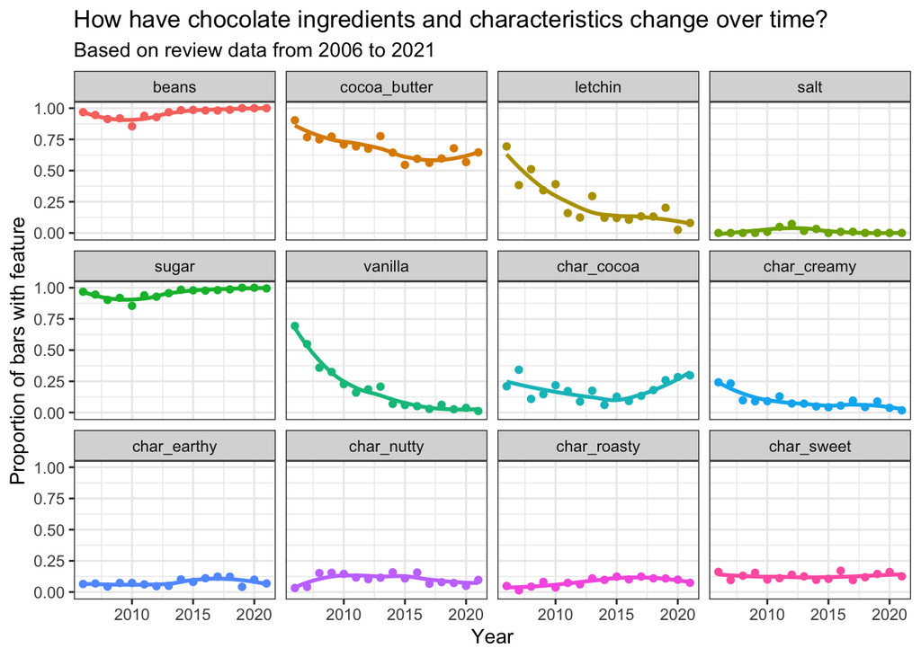

```r
table.mean_ingredients_by_year.long %>%
  ggplot(aes(x = review_date, y = mean_score, color = ingredient)) +
  geom_point() +
  geom_smooth(
    method = "loess",
    se = FALSE
  ) +
  facet_wrap(~ingredient) +
  theme_bw() +
  theme(legend.position = "none") +
  labs(title = "How have chocolate ingredients and characteristics change over time?",
       subtitle = "Based on review data from 2006 to 2021",
       x = "Year",
       y = "Proportion of bars with feature")
```

**Josh:** Overall, it seems that over the years, less letchin and vanilla are being included in chocolate bars. Cocoa butter has seen as small dip in popularity, but not as pronounced as that of letchin and vanilla. Beans and sugar are, by far, the most popular chocolate ingredient, with nearly every bar including them in their ingredient profile.

## Part 5. Make the worst plot you can!

### 5.1 - 5.2. Create a terrible plot

*Using the chocolate dataset (or any of the modified versions you made throughout this assignment or anything else you wish you build upon it):*

*Make the absolute worst plot that you can. You need to customize it in at least 7 ways to make it awful. In your document, write 1 - 2 sentences about each different customization you added (using bullets – i.e. there should be at least 7 bullet points each with 1-2 sentences), and how it could be useful for you when you want to make an awesome data visualization.*

**Josh:** My terrible plot is shown below.

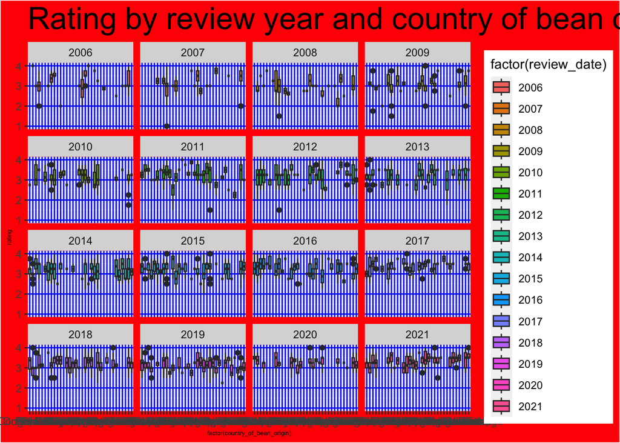

```r
chocolate.with_cont.cobo_geq_10 %>%
  ggplot(aes(x = factor(country_of_bean_origin), fill = factor(review_date), y = rating)) +
  geom_boxplot() +
  facet_wrap(~review_date) +
  labs(title = "Rating by review year and country of bean origin") +
  theme(axis.title.y = element_text(size = 5),
        axis.title.x = element_text(size = 5),
        panel.grid.major = element_line(color = "blue"),
        plot.background = element_rect(fill = "red"),
        plot.title = element_text(size = 25))
```

**Josh:** Here are the customizations I made.

1. `aes(x = factor(country_of_bean_origin), fill = factor(review_date), y = rating)`: I created a boxplot with `country_of_bean_origin` on the x-axis, `rating` on the y-axis, and `review_date` as the fill variable. There are 34 countries, and 16 review dates, so the plot will contain 34 * 16 = 544 boxes (assuming there is data for every country-year combo). This will be useful for making a great data visualization because it will allow me to easily toggle how I define my x, y, and fill variables.
2. `geom_boxplot()` This customization created a boxplot from my ggplot object. I think this method of creating a boxplot is particularly useful because it is so easy to customize.
3. `facet_wrap(~review_date)` I used this to create 16 facets, each defined by a specific year between 2006 and 2021. This customization is useful for separating visualizations by groups and makes it easier to see relationships within groups.
4. `axis.title.y = element_text(size = 5)` I made the y-axis label have a font-size of 5. This makes it very small and therefore difficult to read. A better plot would have a larger font size.
5. `axis.title.x = element_text(size = 5)` I also made the x-axis label have a font-size of 5. Again, a better plot would have a larger font size.
6. `panel.grid.major = element_line(color = "blue")` This changed the color of the grid lines on each facet. Not really necessary for this plot, but could be necessary if the analyst wants to make it easier to read coordinates on the plot.
7. `plot.background = element_rect(fill = "red")` Makes the canvas red. This is completely unnecessary for this plot, and makes it look quite ugly. I suppose this specification could be useful if someone wants to adjust the contrast between their plot and the canvas.
8. `plot.title = element_text(size = 25)` I made the title have a font-size of 25. This is simply too large for this already overloaded plot. A better visualization would use a smaller font size for the title.

## Part 6. Make my plot better!

### 6.1 - 6.2. Improve a plot

*The goal is to take my sad looking plot and make it better!*

*You need to customize it in at least 7 ways to make it better. In your document, write 1 - 2 sentences about each different customization you added (using bullets – i.e. there should be at least 7 bullet points each with 1-2 sentences), describing how you improved it.*

**Josh:** I’ve reposted the original plot for reference:

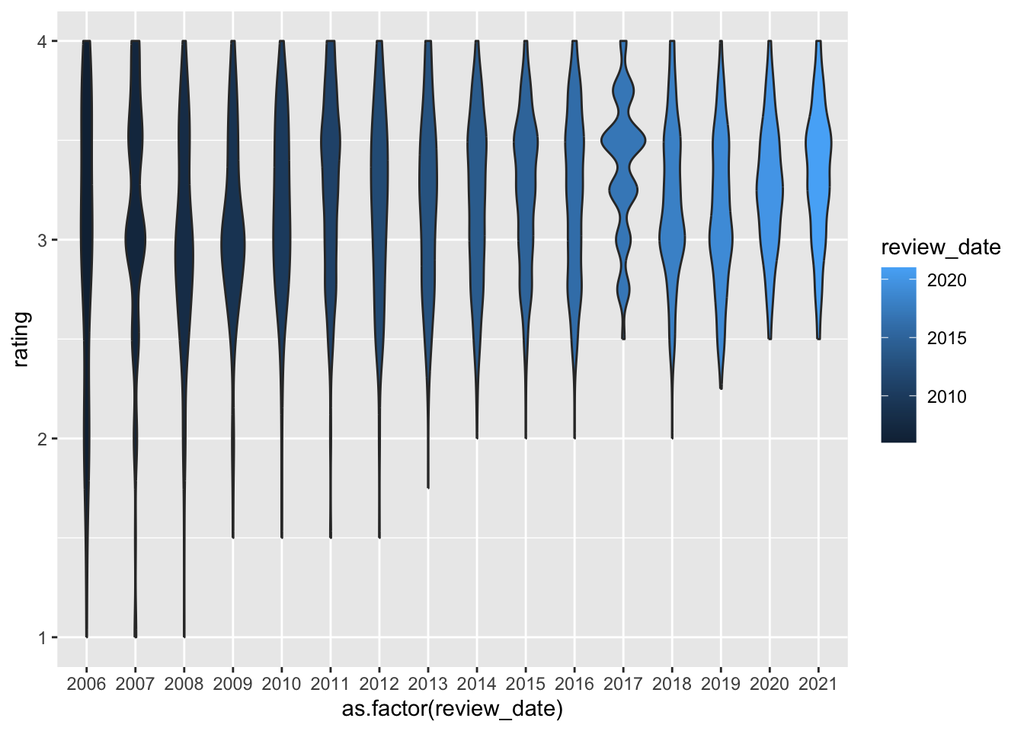

```r
chocolate %>%
    ggplot(aes(
        x = as.factor(review_date),
        y = rating,
        fill = review_date
    )) +
    geom_violin()
```

**Josh:** And here is my new-and-improved plot.

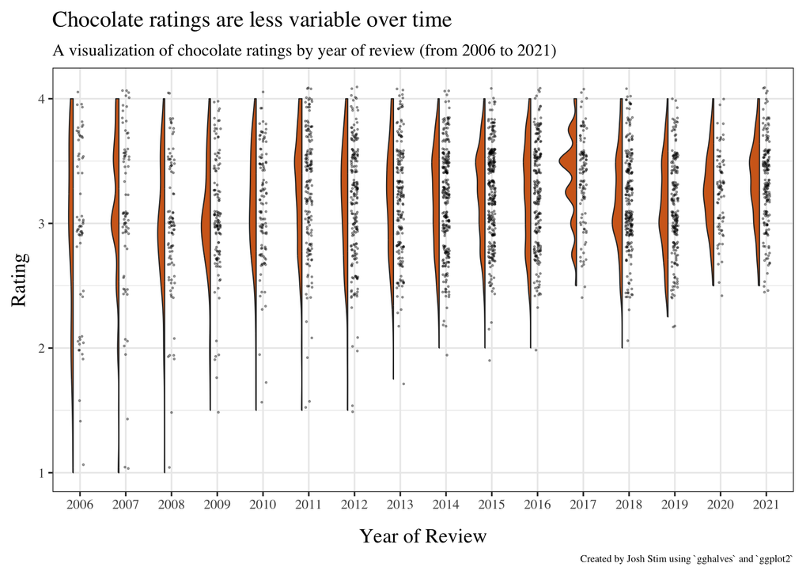

```r
chocolate %>%
  ggplot(aes(
      x = as.factor(review_date),
      y = rating
    )) +
  geom_half_violin(position = position_nudge(x = -0.15), fill = "chocolate") +
  geom_jitter(size = 0.5, width = 0.075, alpha = 0.35) +
  labs(title = "Chocolate ratings are less variable over time",
       subtitle = "A visualization of chocolate ratings by year of review (from 2006 to 2021)",
       caption = "Created by Josh Stim using `gghalves` and `ggplot2`") +
  xlab("Year of Review") +
  ylab("Rating") +
  theme_bw(base_family = "Times", base_size = 15) +
  theme(axis.title.x = element_text(size = 18, vjust = -2),
        axis.title.y = element_text(size = 18, vjust = 2),
        axis.text.x = element_text(size = 12),
        axis.text.y = element_text(size = 12),
        plot.caption = element_text(size = 9, vjust = -5),
        plot.title = element_text(size = 20, vjust = 2),
        plot.margin = unit(c(0.2, 0.2, 0.2, 0.2), "inches"))
```

```r
options(width = 120)
```